# Position functions

Advanced nudging

Pedro J. Aphalo

2021-11-12

## Preliminaries

As we will use text and labels on the plotting area we change the default theme to an uncluttered one.

```r
library(ggpp)
library(ggrepel)
old_theme <- theme_set(theme_bw())
```

## Nudge position functions

Nudging systematically shifts the coordinates giving an *x* and/or *y* position and also expands the limits of the corresponding scales to match. By default in ‘ggplot2’ geometries and position functions no nudging is applied.

Function `position_nudge()` from package ‘ggplot2’ simply applies the nudge, or *x* and/or *y* shifts based directly on the values passed to its parameters `x` and `y`. Passing arguments to the `nudge_x` and/or `nudge_y` parameters of a geometry has the same effect as these values are passed to `position_nudge()`. Geometries also have a `position` parameter to which we can pass an expression based on a *position function* which opens the door to more elaborate approaches to nudging.

We can do better than simply shifting all data to the same extent and direction. For example, by using a point or line as a reference from which the nudge should be applied. In `position_nudge_center()` and `position_nudge_liner()` described below, this reference alters only the direction (angle) along which nudge is applied but not the extent of the shift.

These functions can be used with any geometry but if segments joining the labels to the points are desired `geom_text_repel()` or `geom_label_repel()` should be used, possibly setting `max.iter = 0` if no repulsion is desired. Plotting of short segments can be forced with `min.segment.length = 0`. Please see the documentation for these functions for details.

### position_nudge_keep()

Function `position_nudge_keep()` is like `ggplot2::position_nudge()` but keeps the original *x* and *y* coordinates. It is similar to function `position_nudge_repel()` but uses a different naming convention for the coordinates. Both work with `geom_text_repel()` or `geom_label_repel()` but only `position_nudge_keep()` can be used interchangeably with `ggplot2::position_nudge()`.

```r
set.seed(84532)
df <- data.frame(
  x = rnorm(20),
  y = rnorm(20, 2, 2),
  l = paste("label:", letters[1:20])
)
```

With `position_nudge_keep()` used together with `geom_text_repel()` or `geom_label_repel()` segments between a nudged and/or repelled label and the original position (here indicated by a point) are drawn.

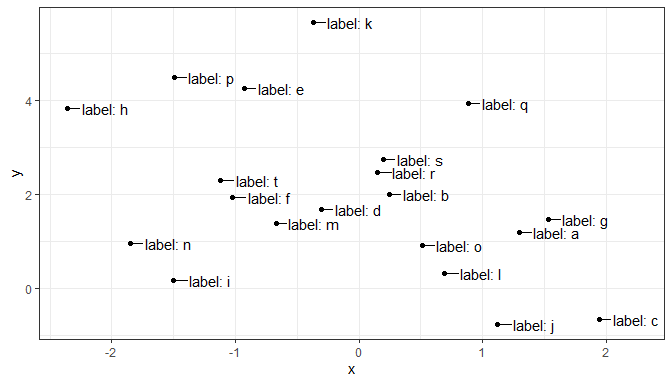

```r
ggplot(df, aes(x, y, label = l)) +
  geom_point() +
  geom_text_repel(position =
                    position_nudge_keep(x = 0.3),
                    min.segment.length = 0, max.iter = 0)
```

With `position_nudge()` used together with `geom_text_repel()` or `geom_label_repel()` segments connecting a nudged and/or repelled label and the original position (here indicated by a point) are **not** drawn.

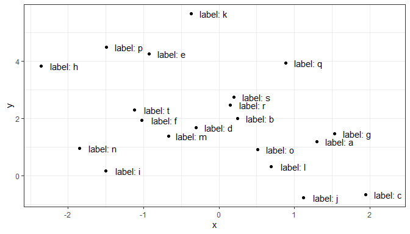

```r
ggplot(df, aes(x, y, label = l)) +
  geom_point() +
  geom_text_repel(position = position_nudge(x = 0.3),
                  min.segment.length = 0,
                  max.iter = 0)
```

`position_nudge_keep()` and all other position functions described below can be used with all ‘ggplot2’ geometries but the original position will be ignored and no connecting segment drawn unless the geometry has been designed to work together with them.

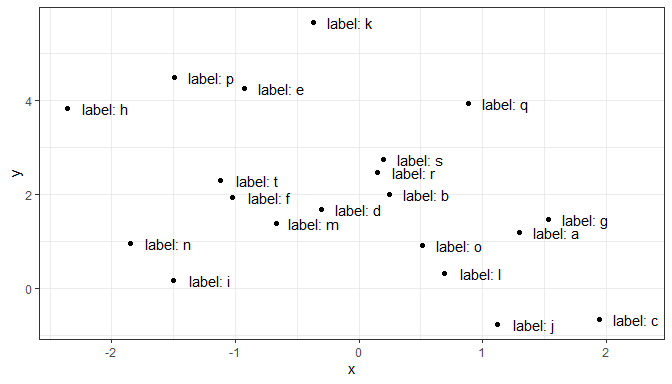

```r
ggplot(df, aes(x, y, label = l)) +
  geom_point() +
  geom_text(position = position_nudge(x = 0.3))
```

### position_nudge_to()

Function `position_nudge_to()` nudges to a given position instead of using the same shift for each observation. Can be used to align labels for points that are not themselves aligned. By left-justifying the label text we ensure the alignment of labels differing in width.

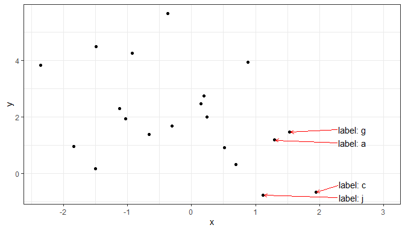

```r
ggplot(df, aes(x, y, label = ifelse(x < 1, "", l) )) +
  geom_point() +
  geom_text_repel(position =
                    position_nudge_to(x = 2.3),
                  min.segment.length = 0,
                  segment.color = "red",
                  arrow = arrow(length = unit(0.015, "npc")),
                  direction = "y",
                  hjust = "left") +
  expand_limits(x = 3)
```

### position_nudge_center()

Function `position_nudge_center()` limits the directions to radiate away from a reference point if both *nudge_x* and *nudge_y* are passed an argument, or if only one of *nudge_x* or *nudge_y* is passed an argument, nudge right and left, or nudge up and down, respectively. By default, the “center” is the centroid computed using `mean()`, but other functions or numeric values can be passed to override it. When data are sparse, such nudging may be effective in avoiding label overlaps, and achieving a visually pleasing positioning.

In all cases nudging shifts the coordinates giving an *x* and/or *y* position and also expands the limits of the corresponding scales to match.

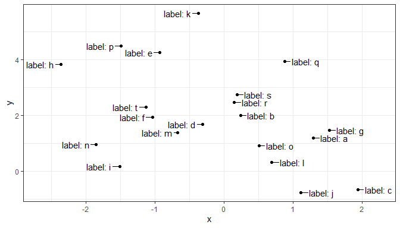

```r
ggplot(df, aes(x, y, label = l)) +
  geom_point() +
  geom_text_repel(position =
                    position_nudge_center(x = 0.3, center_x = 0),
                    min.segment.length = 0, max.iter = 0)
```

By default, split is away or towards the `mean()`. Here we allow repulsion to separate the labels (compare with previous plot).

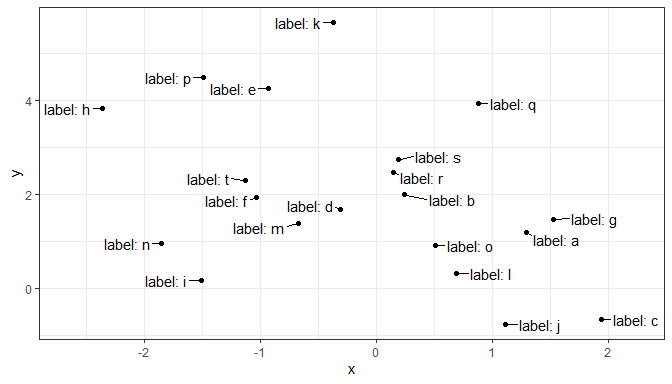

```r
ggplot(df, aes(x, y, label = l)) +
  geom_point() +
  geom_text_repel(position =
                    position_nudge_center(x = 0.3,
                                          direction = "split"),
                  min.segment.length = 0)
```

We set a different split point as a constant value.

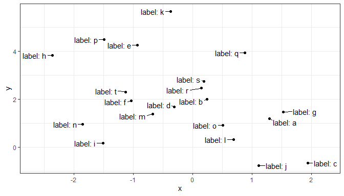

```r
ggplot(df, aes(x, y, label = l)) +
  geom_point() +
  geom_text_repel(position =
                    position_nudge_center(x = 0.3,
                                          center_x = 1,
                                          direction = "split"),
                  min.segment.length = 0)
```

We set a different split point as the value computed by a function function, by name.

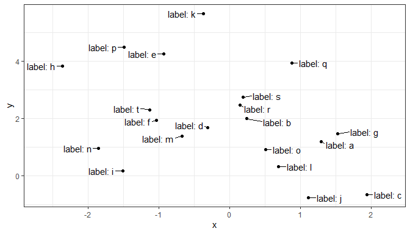

```r
ggplot(df, aes(x, y, label = l)) +
  geom_point() +
  geom_text_repel(position =
                    position_nudge_center(x = 0.3,
                                          center_x = median,
                                          direction = "split"),
                  min.segment.length = 0)
```

We set a different split point as the value computed by an anonymous function function. Here que split on the first quartile along *x*.

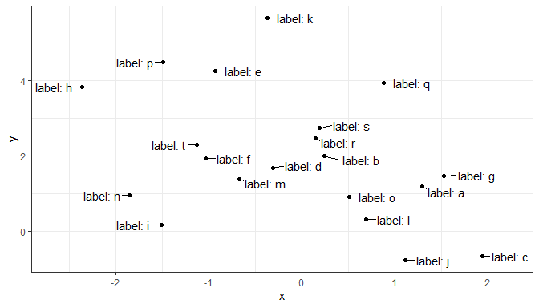

```r
ggplot(df, aes(x, y, label = l)) +
  geom_point() +
  geom_text_repel(position =
                    position_nudge_center(x = 0.3,
                                          center_x = function(x) {
                                            quantile(x,
                                                     probs = 1/4,
                                                     names = FALSE)
                                          },
                                          direction = "split"),
                  min.segment.length = 0)
```

The labels can be rotated as long as the geometry used supports this.

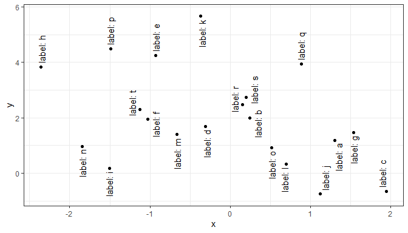

```r
ggplot(df, aes(x, y, label = l)) +
  geom_point() +
  geom_text_repel(angle = 90,
                  position =
                    position_nudge_center(y = 0.1,
                                          direction = "split"))
```

By requesting nudging along *x* and *y* and setting `direction = "split"` nudging is applied according to the quadrants centred on the centroid of the data.

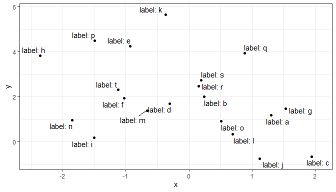

```r
ggplot(df, aes(x, y, label = l)) +
  geom_point() +
  geom_text_repel(position =
                    position_nudge_center(x = 0.1,
                                          y = 0.15,
                                          direction = "split"))
```

With `direction = "radial"`, the distance nudged away from the center is the same for all labels.

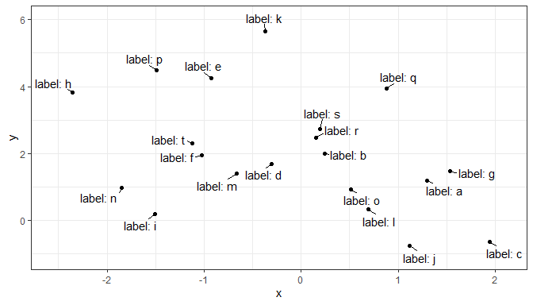

```r
ggplot(df, aes(x, y, label = l)) +
  geom_point() +
  geom_text_repel(position =
                    position_nudge_center(x = 0.25,
                                          y = 0.4,
                                          direction = "radial"),
                  min.segment.length = 0)
```

As shown above for `direction = "split"` we can set the coordinates of the centre by passing constant values as in this example or functions (possibly different for *x* and *y*). We can also set the justification the text labels although repulsion usually works best with labels justified at the centre, which is the default.

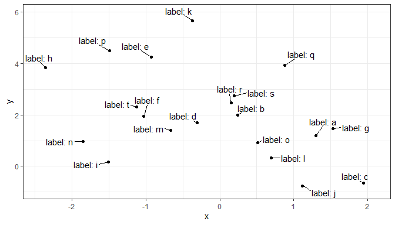

```r
ggplot(df, aes(x, y, label = l)) +
  geom_point() +
  geom_text_repel(position =
                    position_nudge_center(x = 0.15,
                                          y = 0.3,
                                          center_x = 0,
                                          center_y = 0,
                                          direction = "radial"),
                  min.segment.length = 0,
                  hjust = "outward", vjust = "outward")
```

Nudging along one axis, here *x*, and setting the repulsion `direction` along the other axis, here *y*, tends to give a pleasent arrangement of labels.

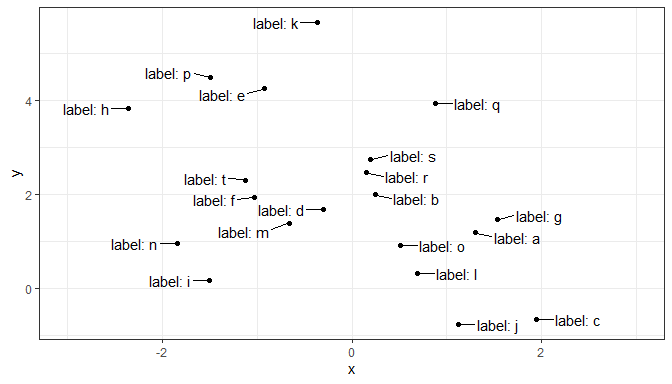

```r
ggplot(df, aes(x, y, label = l)) +
  geom_point() +
  geom_text_repel(position =
                    position_nudge_center(x = 0.2,
                                          center_x = 0,
                                          direction = "split"),
                  aes(hjust = ifelse(x < 0, 1, 0)),
                  direction = "y",
                  min.segment.length = 0) +
  expand_limits(x = c(-3, 3))
```

### position_nudge_line()

Function `position_nudge_line()` nudges away from a line, which can be a user supplied straight line as well as a smooth spline or a polynomial fitted to the observations themselves. The nudging is away and perpendicular to the local slope of the straight or curved line. It relies on the same assumptions as linear regression, assuming that *x* values are not subject to error. This in most cases prevents labels from overlaping a curve fitted to the data, even if not exactly based on the same model fit. When observations are sparse, this may be enough to obtain a nice arrangement of data labels.

```r
set.seed(16532)
df <- data.frame(
  x = -10:10,
  y = (-10:10)^2,
  yy = (-10:10)^2 + rnorm(21, 0, 4),
  yyy = (-10:10) + rnorm(21, 0, 4),
  l = letters[1:21]
)
```

The first, simple example shows that `position_nudge_line()` has shifted the direction of the nudging based on the alignment of the observations along a line. One could, of course, have in this case passed suitable values as arguments to *x* and *y* using `position_nudge()` from package ‘ggplot2’.

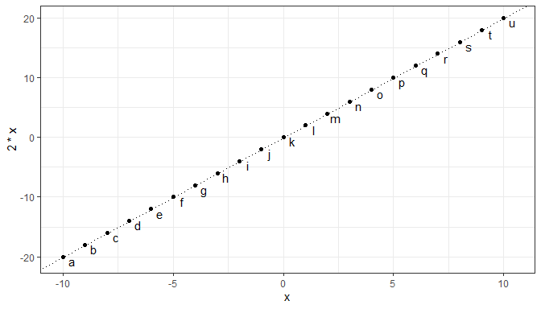

```r
ggplot(df, aes(x, 2 * x, label = l)) +
  geom_point() +
  geom_abline(intercept = 0, slope = 2, linetype = "dotted") +
  geom_text(position = position_nudge(x = 0.4, y = -0.7))
```

Same for `position_nudge_line()`.

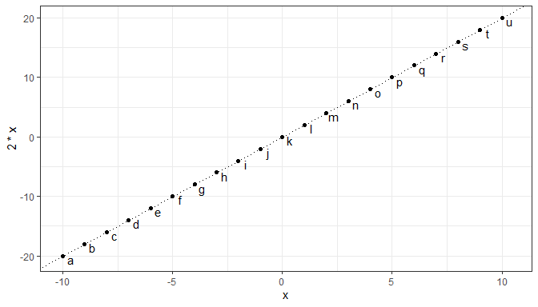

```r
ggplot(df, aes(x, 2 * x, label = l)) +
  geom_point() +
  geom_abline(intercept = 0, slope = 2, linetype = "dotted") +
  geom_text(position = position_nudge_line(x = -0.5, y = -0.8))
```

However, `position_nudge_line()` will work without change irrespective of the slope or intercept along which the observations fall.

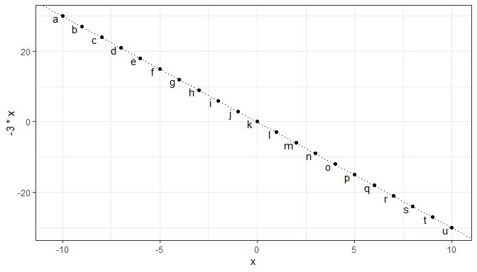

```r
ggplot(df, aes(x, -3 * x, label = l)) +
  geom_point() +
  geom_abline(intercept = 0, slope = -3, linetype = "dotted") +
  geom_text(position = position_nudge_line(x = -0.5, y = -0.8))
```

With observations with high variation in *y*, a linear model fit may need to be used. In this case fitted twice, once in `stat_smooth()` and once in `position_nudge_line()`.

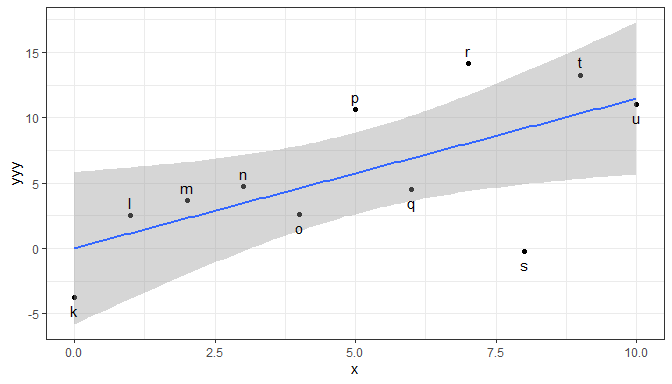

```r
ggplot(subset(df, x >= 0), aes(x, yyy)) +
  geom_point() +
  stat_smooth(method = "lm") +
  geom_text(aes(label = l),
            vjust = "center", hjust = "center",
            position = position_nudge_line(x = 0, y = 1.2,
                                           method = "lm",
                                           direction = "split"))
```

With lower variation in *y*, we can pass to `line_nudge` a multiplier to keep labels outside of the confidence band.

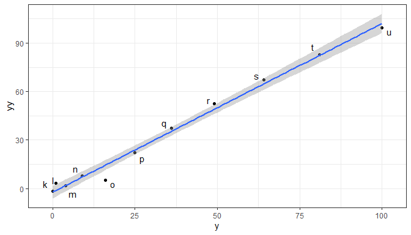

```r
ggplot(subset(df, x >= 0), aes(y, yy)) +
  geom_point() +
  stat_smooth(method = "lm", formula = y ~ x) +
  geom_text(aes(label = l),
            position = position_nudge_line(method = "lm",
                                           x = 3, y = 3,
                                           line_nudge = 2.5,
                                           direction = "split"))
```

If we want the nudging based on an arbitrary straight line not computed from `data`, we can pass the intercept and slope in a numeric vector of length two as an argument to parameter `abline`.

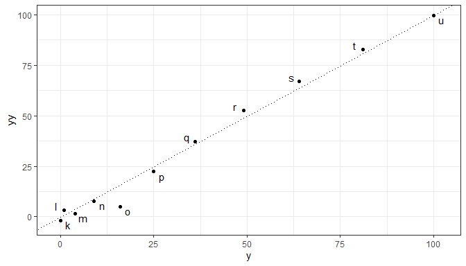

```r
ggplot(subset(df, x >= 0), aes(y, yy)) +
  geom_point() +
  geom_abline(intercept = 0, slope = 1, linetype = "dotted") +
  geom_text(aes(label = l),
            position = position_nudge_line(abline = c(0, 1),
                                           x = 3, y = 3,
                                           direction = "split"))
```

With observations that follow exactly a simple curve the defaults work well to automate the nudging of individual data labels away from the implicit curve. Positive values as arguments to `x` and `y` correspond to above and inside the curve. One could, of course, pass also in this case suitable values as arguments to *x* and *y* using `position_nudge()` from package ‘ggplot2’, but these arguments would need to be vectors with different *nudge* values for each observation.

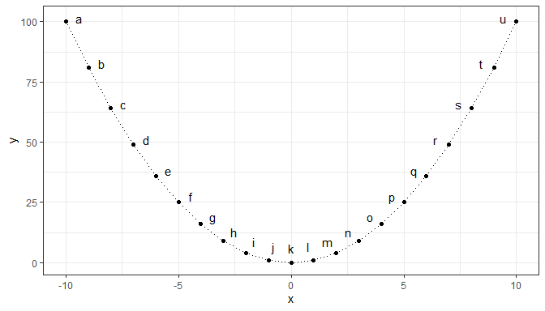

```r
ggplot(df, aes(x, y, label = l)) +
  geom_point() +
  geom_line(linetype = "dotted") +
  geom_text(position = position_nudge_line(x = 0.6, y = 6))
```

Negative values passed as arguments to `x` and `y` correspond to labels below and outside the curve.

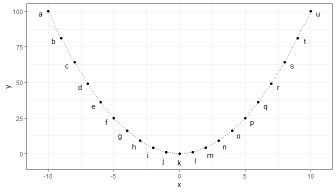

```r
ggplot(df, aes(x, y, label = l)) +
  geom_point() +
  geom_line(linetype = "dotted") +
  geom_text(position = position_nudge_line(x = -0.6, y = -6))
```

When the observations include random variation along *y*, it is important that the smoother used for the line added to a plot and that passed to `position_nudge_line()` are similar. By default `stat_smooth()` uses `"loess"` and `position_nudge_line()` with methid `"spline"`, `smooth.sline()`, which are a good enough match.

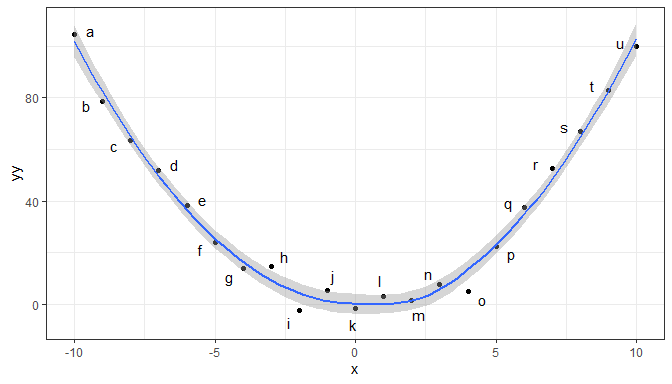

```r
ggplot(df, aes(x, yy, label = l)) +
  geom_point() +
  stat_smooth() +
  geom_text(aes(y = yy, label = l),
            position = position_nudge_line(x = 0.6,
                                           y = 6,
                                           direction = "split"))
```

We can use other geometries.

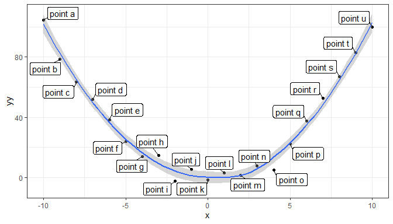

```r
ggplot(df, aes(x, yy, label = l)) +
  geom_point() +
  stat_smooth() +
  geom_label_repel(aes(y = yy, label = paste("point", l)),
            position = position_nudge_line(x = 0.6,
                                           y = 6,
                                           direction = "split"),
            min.segment.length = 0)
```

When fitting a polynomial, `"lm"` should be the argument passed to `method` and a model formula preferably based on `poly()`, setting `raw = TRUE`, as argument to `formula`. *Currently no other methods are implemented in* `position_nudge_line()`.

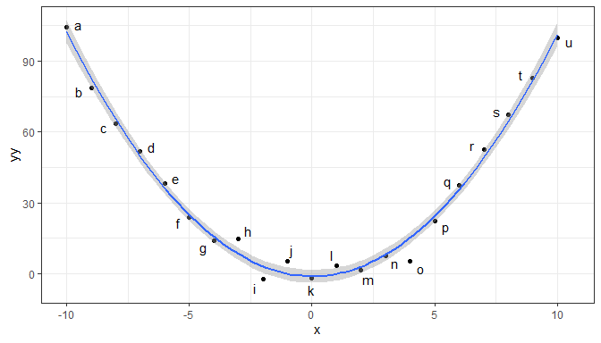

```r
ggplot(df, aes(x, yy, label = l)) +
  geom_point() +
  stat_smooth(method = "lm", formula = y ~ poly(x, 2, raw = TRUE)) +
  geom_text(aes(y = yy, label = l),
            position = position_nudge_line(method = "lm",
                                           x = 0.5,
                                           y = 5,
                                           formula = y ~ poly(x, 2, raw = TRUE),
                                           direction = "split"))
```

Compared to pure repulsion adding nudging helps “direct” repulsion in the desired direction. Compare the two plots bellow using no nudging with the two above.

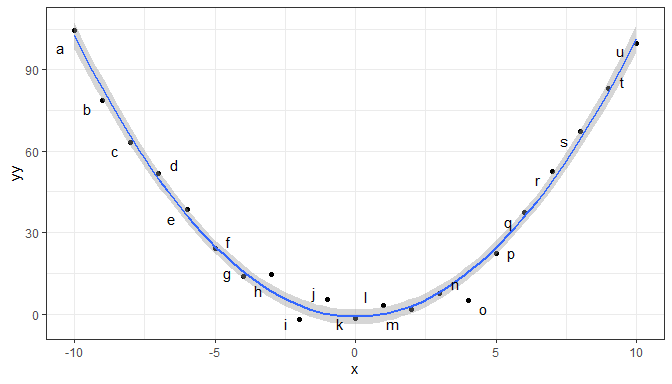

```r
ggplot(df, aes(x, yy, label = l)) +
  geom_point() +
  stat_smooth(method = "lm", formula = y ~ poly(x, 2, raw = TRUE)) +
  geom_text_repel(aes(y = yy, label = l),
                  box.padding = 0.5,
                  min.segment.length = Inf)
```

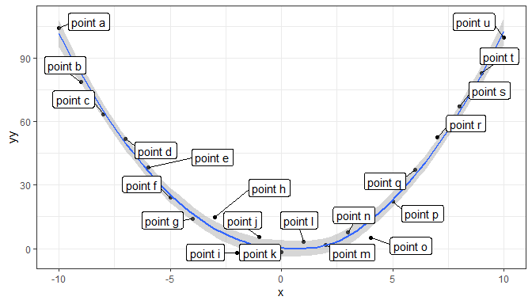

```r
ggplot(df, aes(x, yy, label = l)) +
  geom_point() +
  stat_smooth() +
  geom_label_repel(aes(y = yy, label = paste("point", l)),
                  box.padding = 0.5,
                  min.segment.length = 0)
```

Grouping is supported.

```r
df <- data.frame(x = rep(1:10, 2),
                 y = c(1:10, 10:1),
                 group = rep(c("a", "b"), c(10, 10)),
                 l = "+")
```

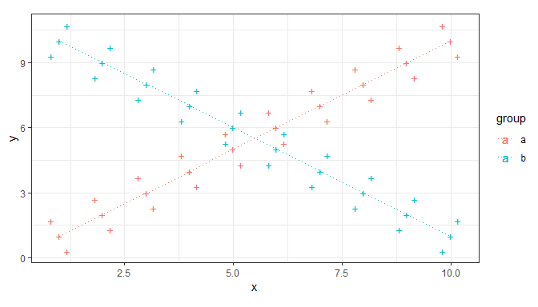

```r
ggplot(df, aes(x, y, label = l, color = group)) +
  geom_line(linetype = "dotted") +
  geom_text() +
  geom_text(position = position_nudge_line(x = 0.25, y = 1)) +
  geom_text(position = position_nudge_line(x = -0.25, y = -1)) +
  coord_equal(ratio = 0.5)
```

One needs to ensure that grouping is in effect in the geoms with nudging.

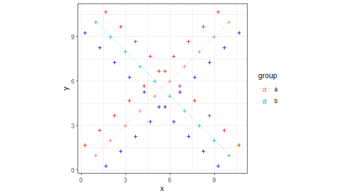

```r
ggplot(df, aes(x, y, label = l, color = group, group = group)) +
  geom_line(linetype = "dotted") +
  geom_text() +
  geom_text(color = "red",
            position = position_nudge_line(x = 1, y = 1)) +
  geom_text(color = "blue",
            position = position_nudge_line(x = -1, y = -1)) +
  coord_equal()
```

Facets are also supported.

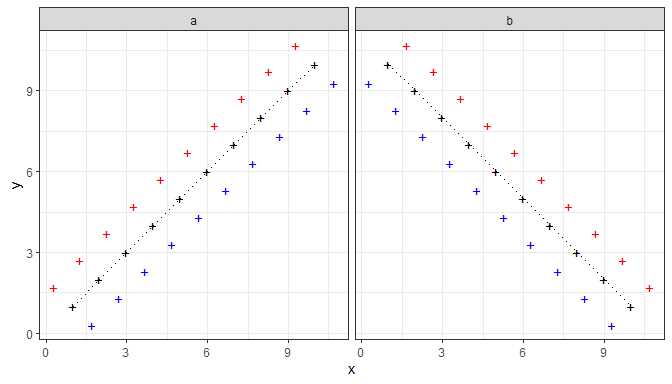

```r
ggplot(df, aes(x, y, label = l)) +
  geom_line(linetype = "dotted") +
  geom_text() +
  geom_text(position = position_nudge_line(x = 1, y = 1),
            color = "red") +
  geom_text(position = position_nudge_line(x = -1, y = -1),
            color = "blue") +
  facet_wrap(~group) +
  coord_equal(ratio = 1)
```